# Áreas de calibración y Ms

Patron-Rivero, C.

2025

# Repositorios

Base disponible en:

https://docs.google.com/spreadsheets/d/1PjsYxYvbF1rIagZKwfuehCEsfQPvOqMSRYtiF8ebZk8/edit?fbclid=IwZXh0bgNhZW0CMTAAAR1a8xPx3uBUsb74sQQobfiCjIpfdivZwX9KfcuTUYHBnTYb5LdO2PUs7-s_aem_f3z8u_E4LUbBd-SdGSv0qA&gid=1543604024#gid=1543604024

|  | Infomación.espacial.de.variables.ambientales | X | X.1 | X.2 | X.3 | X.4 | X.5 | X.6 | X.7 |
| --- | --- | --- | --- | --- | --- | --- | --- | --- | --- |
| 1 | Tipo | NA | ID | Región | Descripción | Resolución espacial | Pagina web | Documentacion |  |
| 2 | Clima | 1 | EarthEnv | Global | Global 1-km Cloud Cover | 1 km | http://www.earthenv.org/cloud | http://journals.plos.org/plosbiology/article?id=10.1371/journal.pbio.1002415 |  |
| 3 |  | 2 | Clima | Sudamérica | Bioclim variables for Southern South America |  | https://www.unil.ch/ecospat/home/menuguid/ecospat-resources/data.html |  |  |
| 28 |  | 28 | Global Aridity Index & Potential Evapotranspiration | Global | Version 3 of the Global Aridity Index and Potential Evapotranspiration Database |  | https://www.nature.com/articles/s41597-022-01493-1#data-availability | https://www.nature.com/articles/s41597-022-01493-1 |  |
| 29 |  | 29 | Sequía | Global | Global Future Drought Layers (CMPI6) |  |  | https://www.nature.com/articles/s41597-025-04612-w |  |
| 30 |  | 30 | MexHiResClimDB | MÉXICO |  |  | https://essd.copernicus.org/articles/17/6911/2025/ |  |  |

# Formatos y resolución

Raster: matriz de celdas (o píxeles) organizadas en filas y columnas en la que cada una contiene un valor que representa información

Resolución: número de pixeles que se utilizan para construir un raster

## Resolución

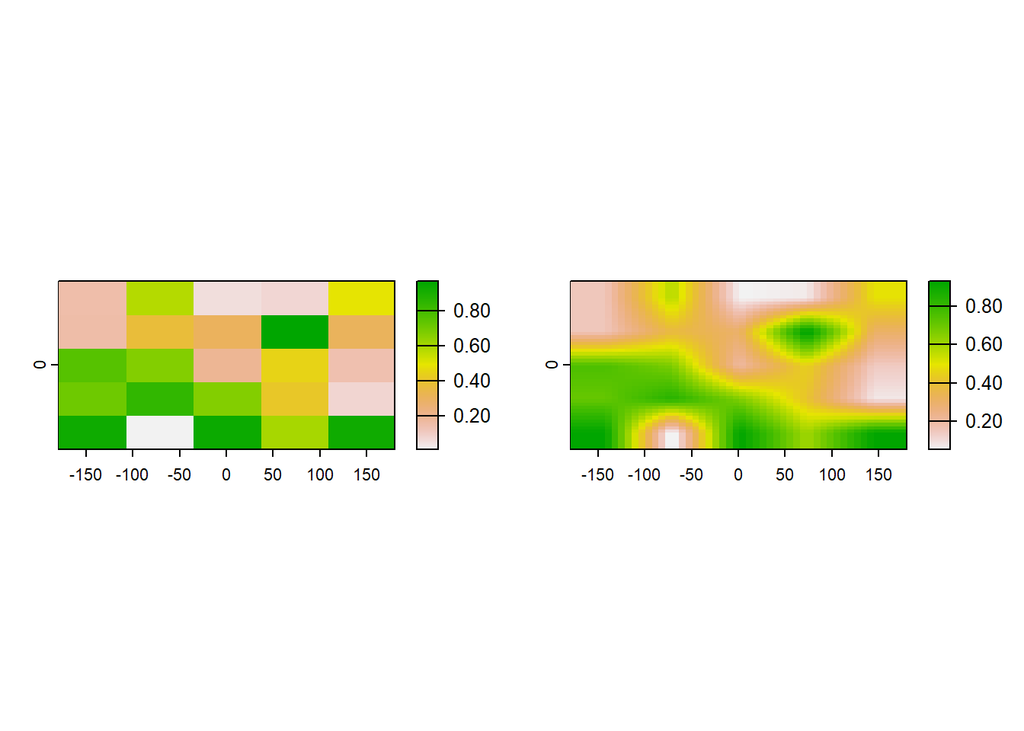

## Escala

```r
library(terra)

setwd("D:/2026_ENM/Calibracion")
m_10 <- rast("./variables/elev_10.tif") # ~340 km2
m_5 <- rast("./variables/elev_5.tif")
m_25 <- rast("./variables/elev_2_5.tif")
s_30 <- rast("./variables/elev_30.tif") # ~1 km2
```

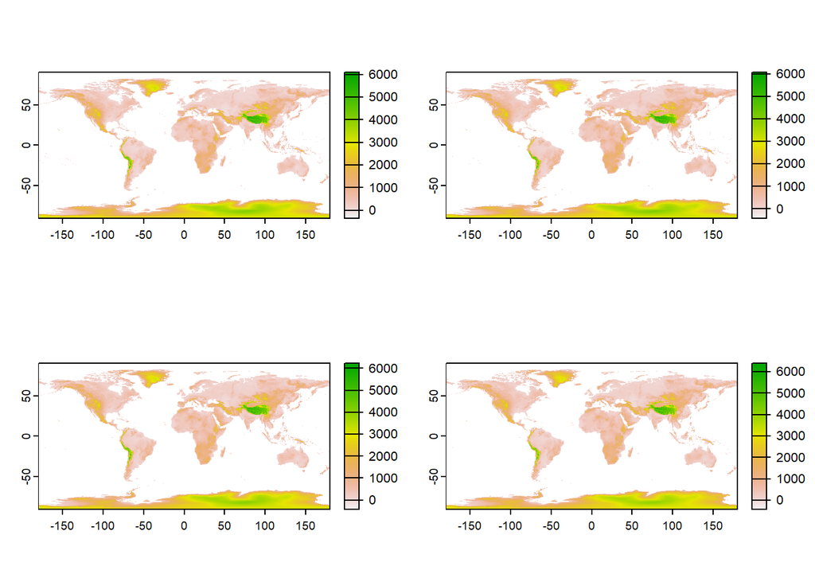

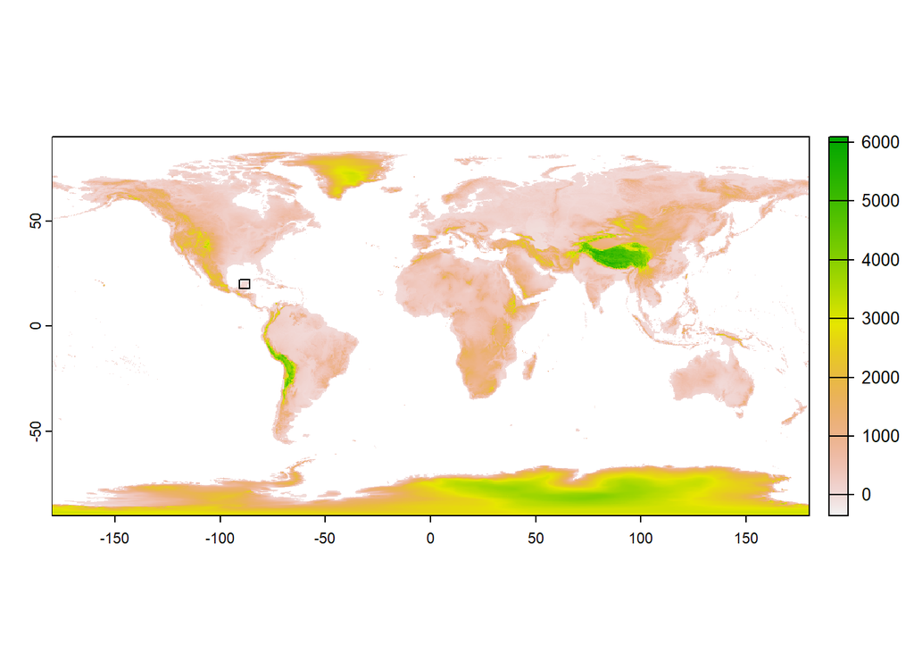

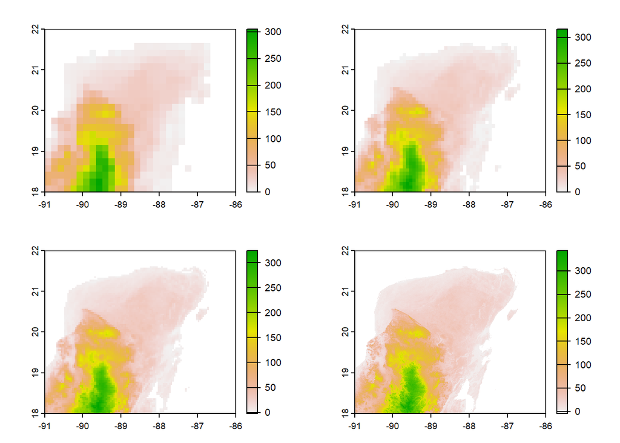

# Cortar variables

## Por extent

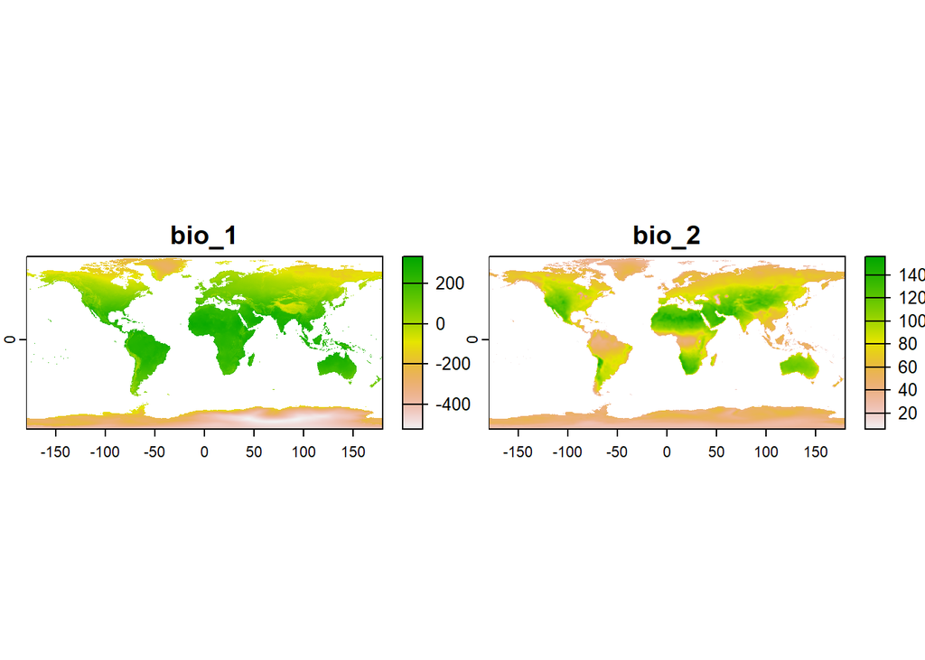

```r
library(terra)

setwd("D:/2026_ENM/Calibracion/variables/set1")
set1 <- list.files(pattern = ".tif")
set1 <- rast(set1)
plot(set1)
```

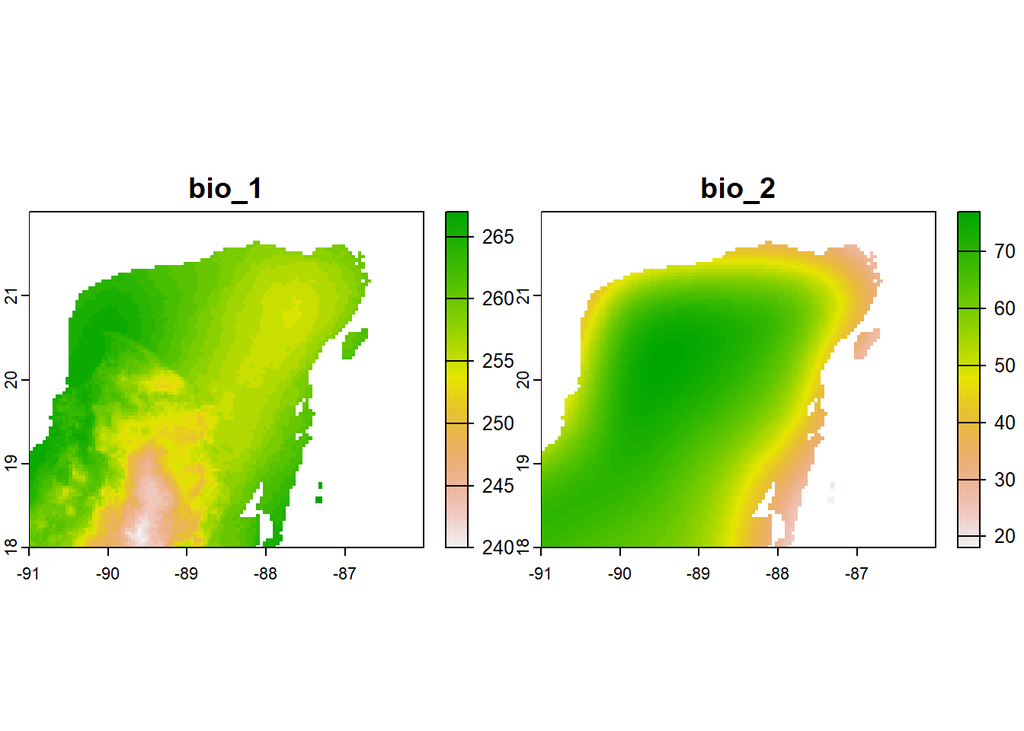

```r
ext1 <- ext(-91, -86, 18, 22)
s1_e1 <- crop(set1, ext1)
plot(s1_e1)
```

## Por polygono (.shp)

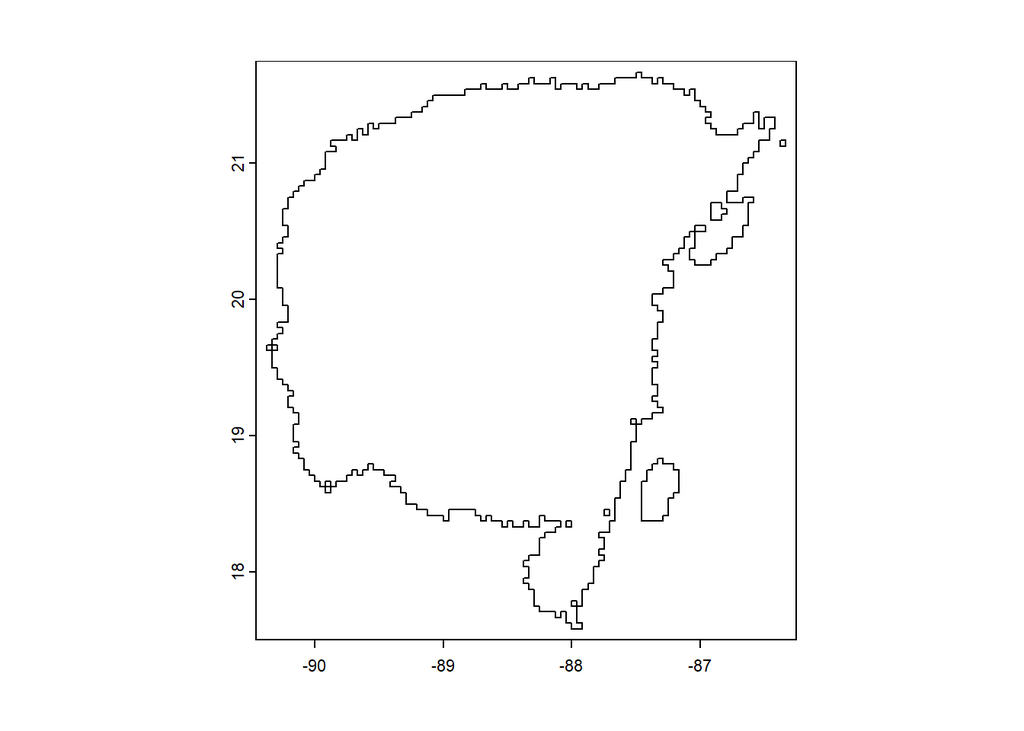

```r
library(terra)

ext2 <- vect("D:/2026_ENM/Calibracion/shp/accessible_area_M.shp")
plot(ext2)
```

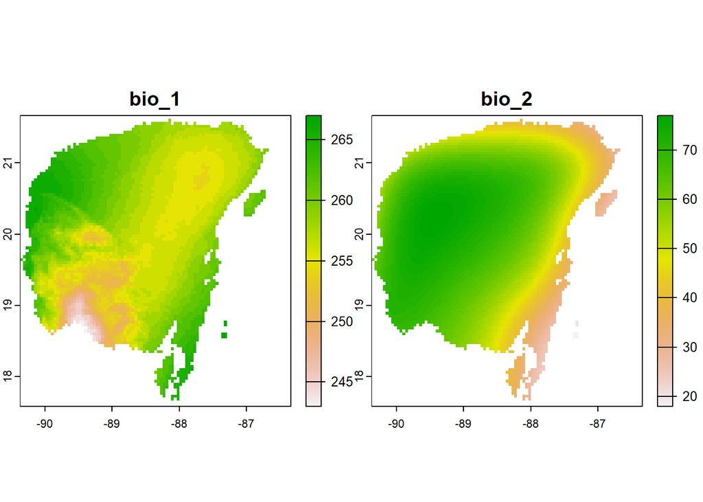

```r
s1_e2 <- crop(set1, ext2, mask = TRUE)
plot(s1_e2)
```

## Por otro raster

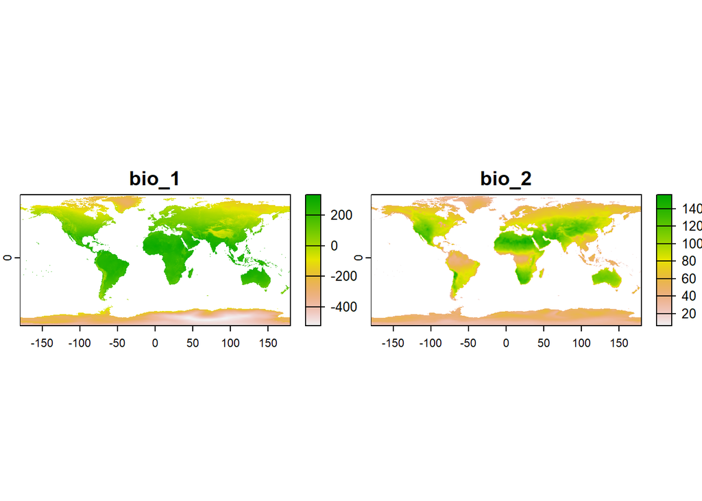

```r
library(terra)

plot(set1)
```

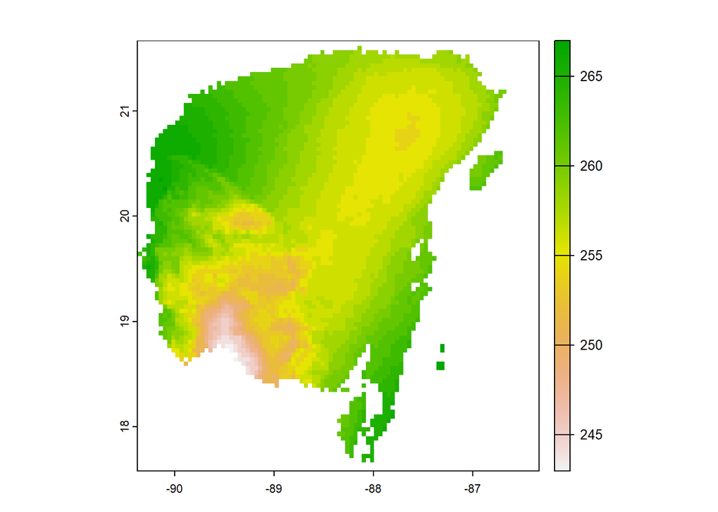

```r
e3 <- s1_e2[[1]]
plot(e3)
```

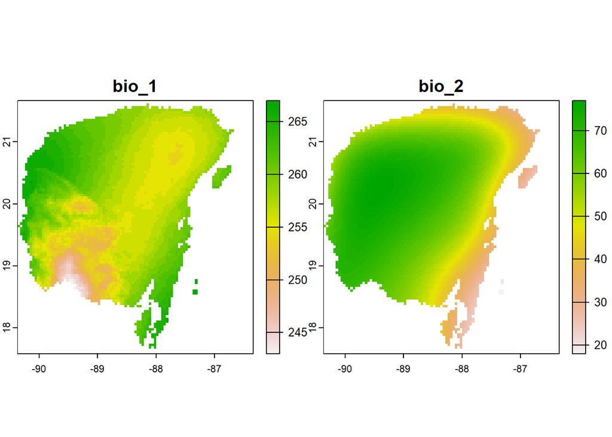

```r
s1_e3 <- crop(set1, e3, mask = TRUE)
plot(s1_e3)
```

# Crear área de calibración y **M** (sensu Soberón & Peterson)

https://onlinelibrary.wiley.com/doi/10.1111/jbi.14834

[figure not shown]

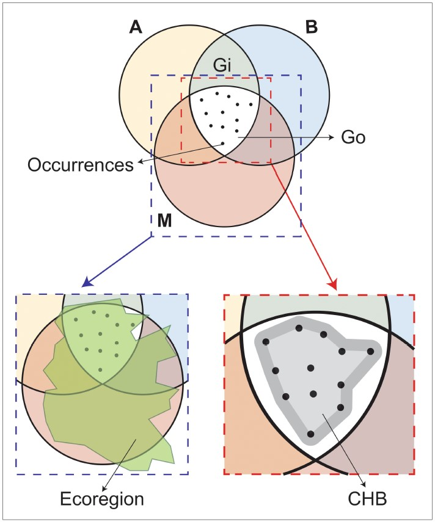

## Buffers / Capacidad de dispersión

```r
#if(!require(ellipsenm)){
#    devtools::install_github("marlonecobos/ellipsenm")
#}

library(terra)
library(ellipsenm)

occ <- read.csv("D:/2026_ENM/Calibracion/P_yuc.csv")
head(occ)
```

```
##   Species      Long      Lat     dtb
## 1   P_yuc -89.01833 18.23667    gbif
## 2   P_yuc -89.44000 18.51000    vnet
## 3   P_yuc -89.43987 18.51069    gbif
## 4   P_yuc -89.72500 19.46361    gbif
## 5   P_yuc -89.72500 19.46361 dig_lit
## 6   P_yuc -88.00796 19.51897    gbif
```

```r
buf_50 <- buffer_area(data = occ, longitude = "Long", latitude = "Lat", buffer_distance = 50)

buf_100 <- buffer_area(data = occ, longitude = "Long", latitude = "Lat", buffer_distance = 100)
```

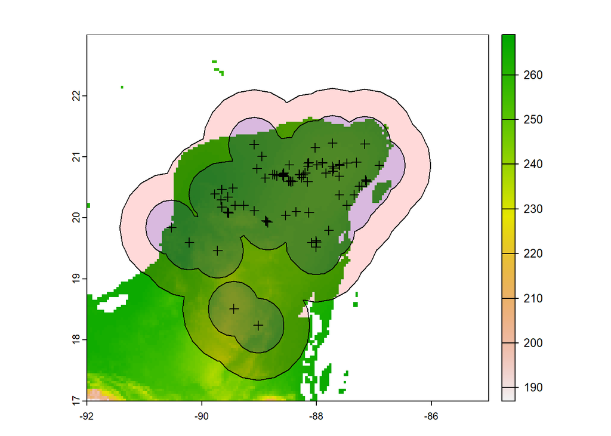

```r
buf_50 <- vect(buf_50)
b50 <- crop(set1, buf_50, mask = TRUE)

buf_100 <- vect(buf_100)
b100 <- crop(set1, buf_100, mask = TRUE)
```

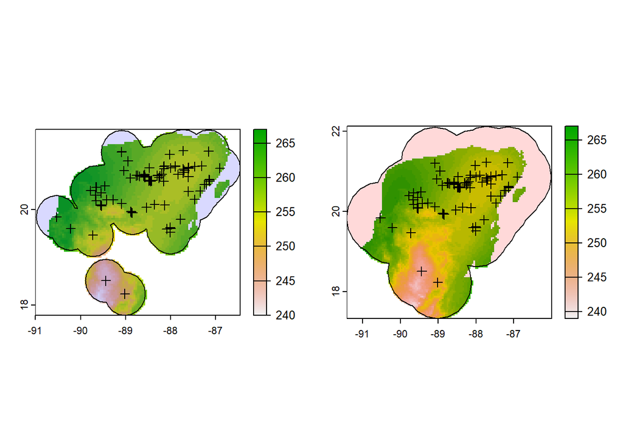

# Sin elipsenm, directo con terra

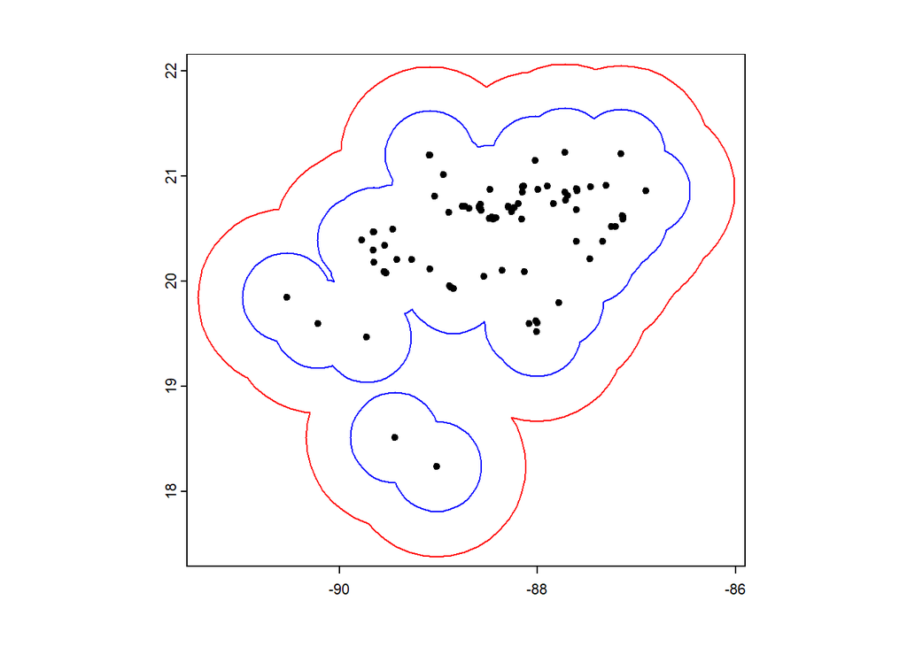

[figure not shown]

```r
library(terra)

points <- vect(occ, geom = c("Long", "Lat"), crs = "EPSG:4326")

points_m <- project(points, "EPSG:3395")  # usa metros

buf_50m <- aggregate(buffer(points_m, width = 50000))    # 50 km
buf_100m <- aggregate(buffer(points_m, width = 100000))  # 100 km

buf_50 <- project(buf_50m, "EPSG:4326")
buf_100 <- project(buf_100m, "EPSG:4326")

b50 <- crop(set1, buf_50, mask = TRUE)
b100 <- crop(set1, buf_100, mask = TRUE)

plot(buf_100, border = "red", col = NA)
plot(buf_50, border = "blue", col = NA, add = TRUE)
plot(points, pch = 20, col = "black", add = TRUE)
```

## Convex hulls

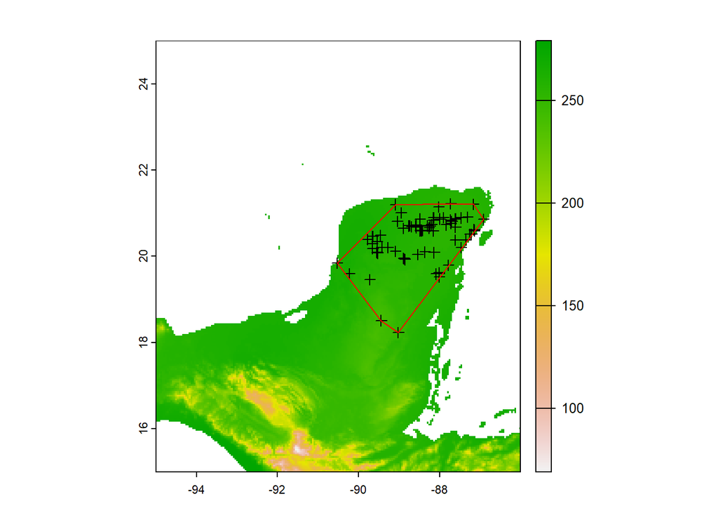

```r
library(sp)
library(terra)

ch <- chull(occ[, 2:3])
coords <- occ[c(ch, ch[1]), ]

plot(set1[[1]], ext = c(-95, -86, 15, 25))
points(occ[, 2:3], pch = 3, add = TRUE)
lines(coords[, 2:3], col="red", add = TRUE)
```

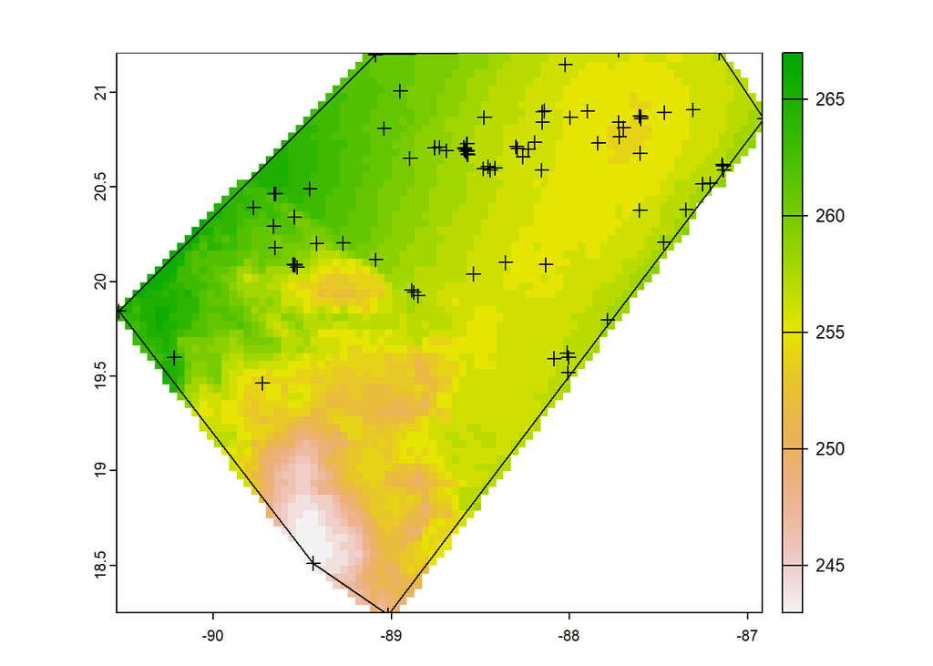

```r
ch_poly <- SpatialPolygons(list(Polygons(list(Polygon(coords[2:3])), ID = 1)), proj4string = CRS("+proj=longlat +datum=WGS84 +no_defs +ellps=WGS84 +towgs84=0,0,0"))

ch_poly <- vect(ch_poly)
ch_M <- crop(set1, ch_poly, mask = TRUE)

plot(ch_M[[1]])
plot(ch_poly, add = TRUE)
points(occ[, 2:3], pch = 3)
```

## Alpha hulls

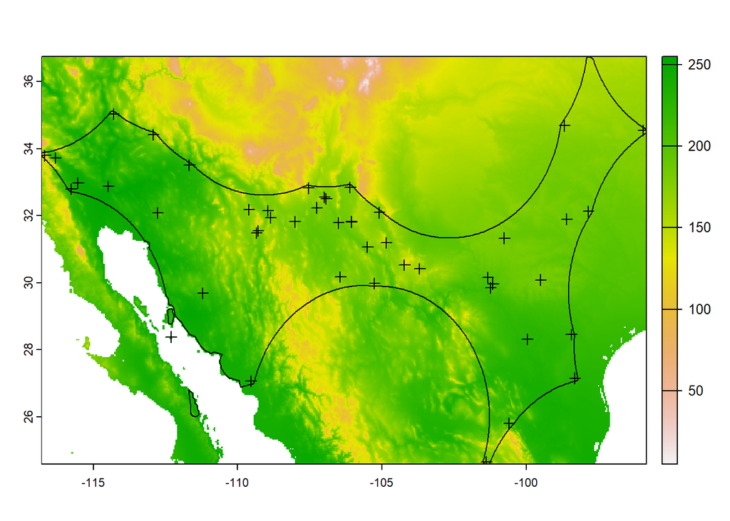

```r
library(terra)
library(rangeBuilder)

cro <- crotalus[which(crotalus$genSp == "Crotalus_atrox"), ]
cro <- cro[sample(1:nrow(cro), 50), ]

ahull <- getDynamicAlphaHull(cro, coordHeaders = c("decimallongitude", "decimallatitude"), clipToCoast = "terrestrial")
ahull_sp <- vect(ahull[[1]])

ah_M <- crop(set1, ahull_sp, mask = TRUE)

plot(set1[[1]], ext = c(-116.8008, -95.8191, 24.56832, 36.73357))
plot(ahull_sp, add = TRUE)
points(cro[, c("decimallongitude", "decimallatitude")], pch = 3)
```

## Presencia en un polígono / Ecorregiones terrestres

Reinos, Provincias y Ecorregiones marinas

https://academic.oup.com/bioscience/article/57/7/573/238419?login=false

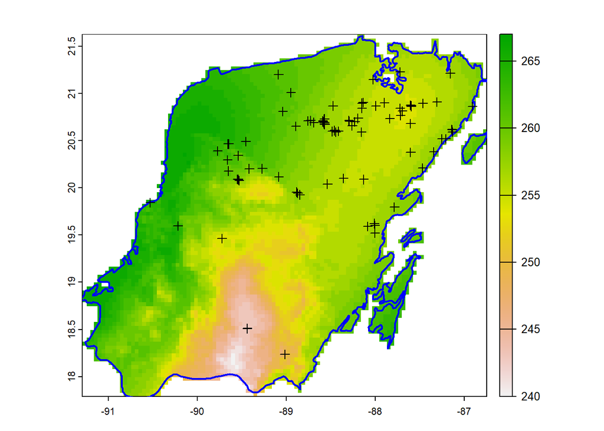

```r
library(terra)

jjm <- vect("D:/2026_ENM/Calibracion/ecoreg/Ecoregions2017.shp")
occ1 <- occ[, 2:3]
occ2 <- vect(as.matrix(occ1), type = "points", crs = "EPSG:4326")
jjm_subset <- jjm[occ2, ]
ecor <- aggregate(jjm_subset)
ecor_M <- crop(set1, ecor, mask = TRUE)
plot(ecor_M[[1]])
plot(ecor, add = TRUE, border = "blue", lwd = 2)
points(occ1, pch = 3)
```

## Grinnel

https://escholarship.org/uc/item/8hq04438

[figure not shown]

**Autómatas celulares**

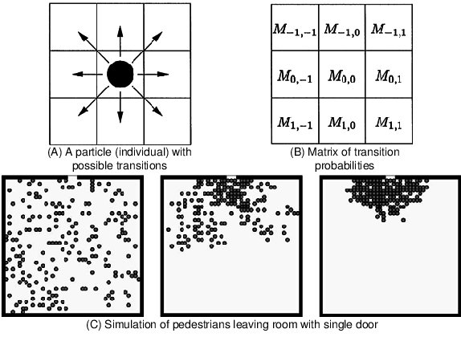

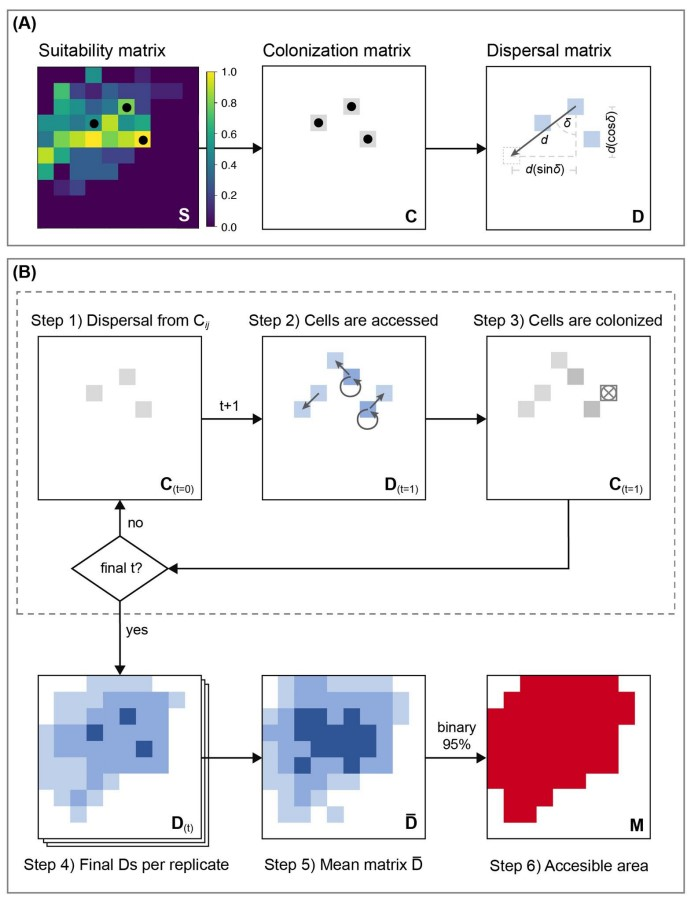

**NOTA:** AQUÍ empiezan los problemas

### Python

Es necesario descargar e instalar Python 3.9 (sólo esta versión)

https://www.python.org/downloads/release/python-3913/

```r
#library(remotes)
#remotes::install_github("fmachados/grinnell")
library(grinnell)
library(raster)
library(parallel)

py.path <- "C:/Users/manol/AppData/Local/Microsoft/WindowsApps/PythonSoftwareFoundation.Python.3.9_qbz5n2kfra8p0"

Sys.setenv(PATH = paste(py.path, Sys.getenv()["PATH"], sep = ";"))

system("python --version")
```

```
## [1] 0
```

```r
system("python -m pip install numpy")
```

```
## [1] 0
```

### Registros y variables

```r
occ <- "E:/5_Curso_ENM/2025/P_6/env_data/P_arc.csv"
cu <- "E:/5_Curso_ENM/2025/P_6/env_data/current"
# Pleistocene: Last Glacial Maximum (ca. 21 ka)
past <- "E:/5_Curso_ENM/2025/P_6/env_data/past_lgm"

#dir.create("E:/5_Curso_ENM/2025/P_6/env_data/sim")
odir1 <- "E:/5_Curso_ENM/2025/P_6/env_data/sim"
```

### Configurar la simulación

**‘kernel_spread’** distancia en pixeles al pixel original (2 = 24 pixeles)

**‘max_dispersers’** número de disperciones aceptadas por cada evento de dispersión (6 = 1/4 de las posibilidades)

**‘replicates’** número de réplicas para calcular S (cada réplica inicia con un “starting population” diferente)

**‘dispersal_events’** número de eventos de dispersión a lo largo de tu ST (20 eventos por año X n ka)

**‘simulation_period’** tiempo que dura la simulación (unidad en miles de años). 21 porque nuestra primera variable es de hace 21 ka

**‘stable_lgm’** tiempo en el que el mis condiciones en el pasado se mantienen.

**‘transition_to_lgm’** Tiempo de transición entre el periodo en el pasado al presente. 3 ka

**‘lgm_to_current’** Tiempo total del pasado hasta el presente. 21 ka

**‘stable_current’** Total de tiempo en el que las condiciones ambientales en el presente han estado estables. Alrededor de 2 ka

**‘scenario_span’** Total de tiempo desde el pasado hasta el presente. 21 ka al presente y 2 ka del actual = 23.

```r
M_simulation(data = occ, current_variables = cu,
             project = TRUE, projection_variables = past,
             kernel_spread = 2, max_dispersers = 6,
             replicates = 5, dispersal_events = 420,
             simulation_period = 21, stable_lgm = 10,
             transition_to_lgm = 3, lgm_to_current = 21,
             stable_current = 2, scenario_span = 23,
             output_directory = odir1)
```

### Resultados

Construye un enm con mve

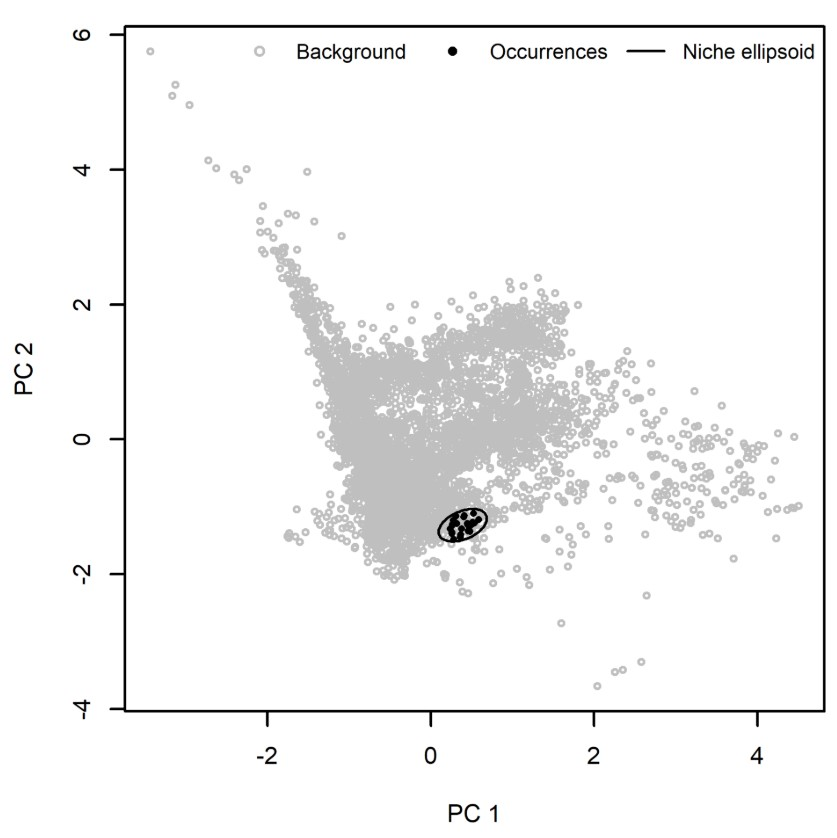

Simula

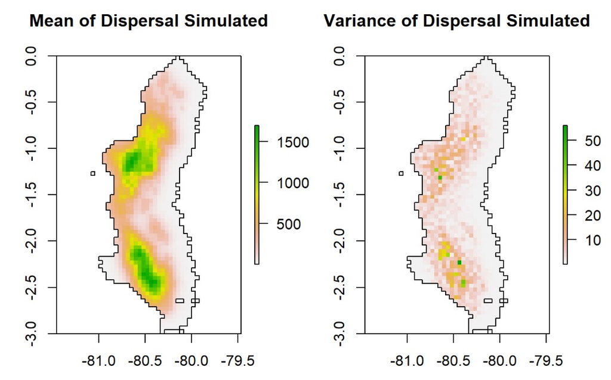

```r
library(raster)
library(rgdal)

setwd("E:/5_Curso_ENM/2025/P_6/env_data/sim")
shp <- readOGR("./accessible_area_M.shp")

m_disp <- raster("./A_mean_S1.asc")
m_disp1 <- mask(crop(m_disp, shp), shp)

v_disp <- raster("./A_var_S1.asc")
v_disp1 <- mask(crop(v_disp, shp), shp)

par(mfrow = c(1, 2))
plot(m_disp1, main = "Mean of Dispersal Simulated")
plot(shp, add = TRUE)
plot(v_disp1, main = "Variance of Dispersal Simulated")
plot(shp, add = TRUE)
```

Con datos a 7 escenarios al pasado

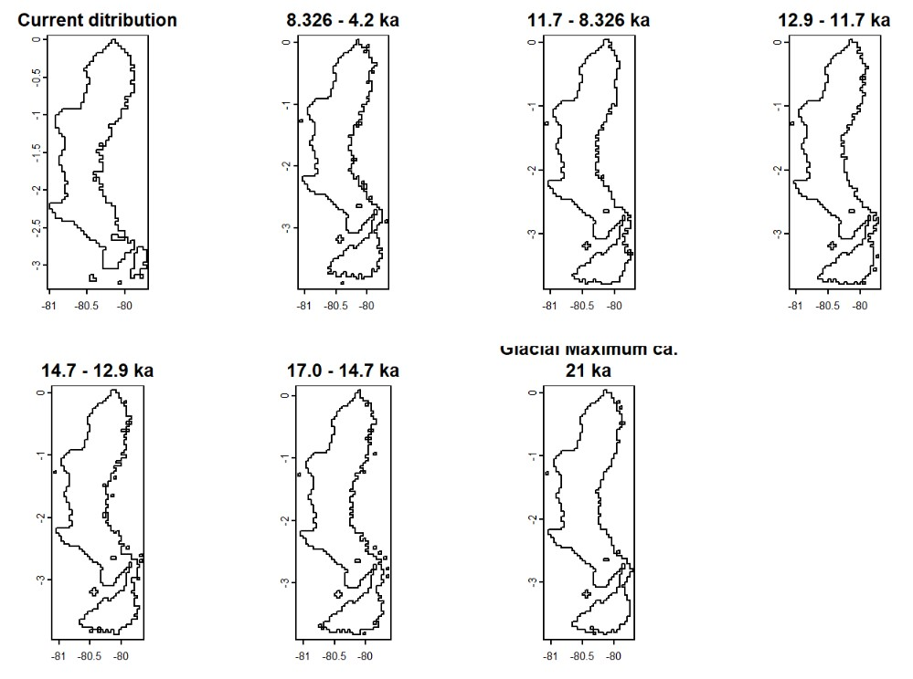

```r
library(raster)
library(rgdal)

setwd("E:/5_Curso_ENM/2025/P_6/env_data/P_arc")

d1 <- vect("./p1", "accessible_area_M")
d2 <- vect("./p2", "accessible_area_M")
d3 <- vect("./p3", "accessible_area_M")
d4 <- vect("./p4", "accessible_area_M")
d5 <- vect("./p5", "accessible_area_M")
d6 <- vect("./p6", "accessible_area_M")
d7 <- vect("./p7", "accessible_area_M")

par(mfrow = c(2, 4))
plot(d1, main = "Current ditribution")
plot(d2, main = "8.326 - 4.2 ka")
plot(d3, main = "11.7 - 8.326 ka")
plot(d4, main = "12.9 - 11.7 ka")
plot(d5, main = "14.7 - 12.9 ka")
plot(d6, main = "17.0 - 14.7 ka")
plot(d7, main = "Glacial Maximum ca.
21 ka")
```

# Guardar nuestros resultados

```r
library(raster)

ecor_M <- raster::stack(ecor_M)

setwd("D:/2026_ENM/Calibracion/variables/ecor")
writeRaster(ecor_M, filename = names(ecor_M), bylayer = T, format = "GTiff", overwrite = TRUE)
```